# Traffic Crashes EDA

Final Project  
Data Science 1 with R (STAT 301-1)

Author

Hannah Ma

Published

December 7, 2023

**Github Repo Link**

https://github.com/stat301-1-2023-fall/final-project-1-Hanyuyuu

## 1 Introduction

My EDA explores over 700,000 traffic crashes in a high-quality dataset from the City of Chicago. My motivation was driven by the culture shock I experienced coming to college from a smaller city, regarding the much more aggressive driving in Chicago. Taken aback by the difference in behavior, when I found this dataset I thought it would be a good opportunity to better understand the landscape of traffic crashes in Chicago. My research question broadly investigates **“What are the primary predictors of traffic crashes in Chicago”**, through a series of several targeted questions which hopefully bring about a more holistic understanding of the traffic crashes in Chicago.

Once again, this dataset works primarily from a large CSV file from the City of Chicago.<sup>1</sup> Visualizations using map data are taken from the `tigris` and `mapview` R packages, with more information provided in Section 4.8 “Where are crashes occurring?”

## 2 Data overview & quality

Table 1: Table of variables with >50% data missing

| Variable | Number of Missing Observations | Percent Missing |
| --- | --- | --- |
| workers_present_i | 774157 | 99.9 |
| dooring_i | 772910 | 99.7 |
| work_zone_type | 771805 | 99.5 |
| work_zone_i | 770806 | 99.4 |
| photos_taken_i | 765283 | 98.7 |
| statements_taken_i | 758338 | 97.8 |
| not_right_of_way_i | 739388 | 95.4 |
| crash_date_est_i | 717030 | 92.5 |
| intersection_related_i | 597673 | 77.1 |
| lane_cnt | 576305 | 74.3 |
| hit_and_run_i | 533170 | 68.8 |

## 3 Explorations

### 3.1 At First Glance

The words “traffic crash” oft conjure gruesome images of upturned cars, flashing police lights, twisted metal, and broken vehicle parts littering the street. The representative image of a “traffic accident” is likely for many readers to be reminiscent of the shocking images seen in driver’s school used to scare new drivers into taking extra precaution on the road. Fortunately, this dataset reminds us that the vast majority of traffic accidents do not look like this. Univariate analyses of variables most relevant and/or salient to a traffic accident are presented below. First, notice that the overwhelming majority of traffic accidents do not lead to injury.

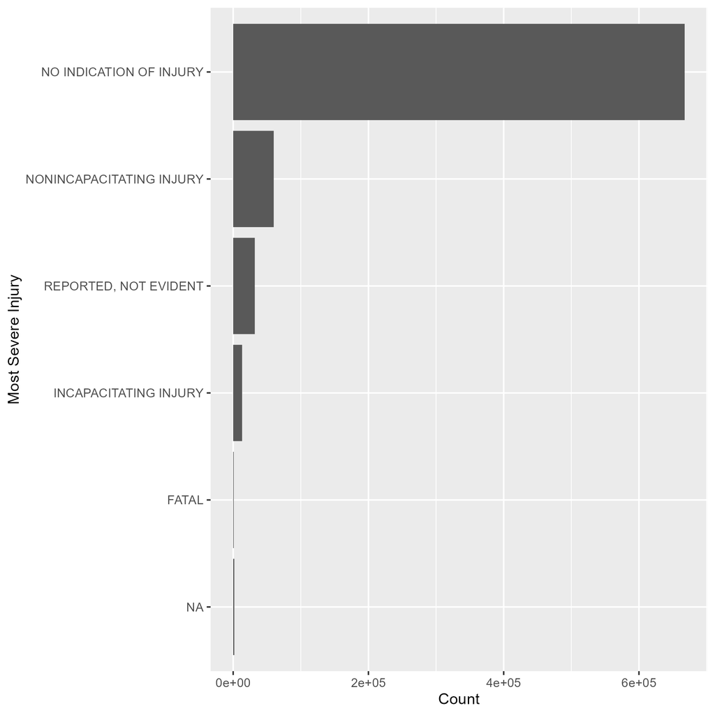

Figure 1: Distribution of Most Severe Injury

Figure 2 illustrates that the overwhelming majority of crashes also occur in clear weather, during daylight, and on dry roads, indicating that inclement weather and darkness are not disproportionately heavy predictors of traffic crashes. Most crashes do occur when there are no traffic lights or other devices nearby to modulate traffic, but crashes occurring near perfectly functional devices make up the second-largest category on this list. Crashes occurring near broken or otherwise non-functional traffic control devices only make up a small proportion of the data, which offers a positive outlook for the vast majority of crashes.

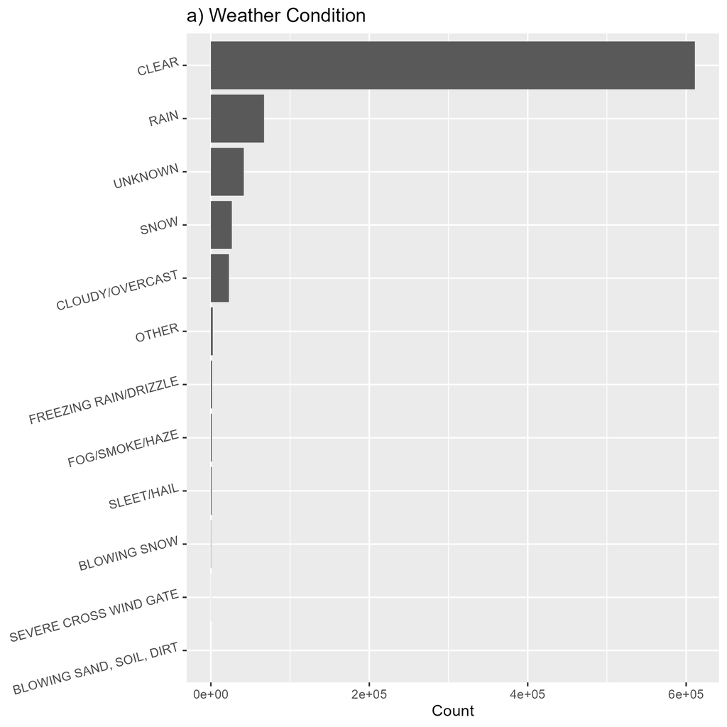

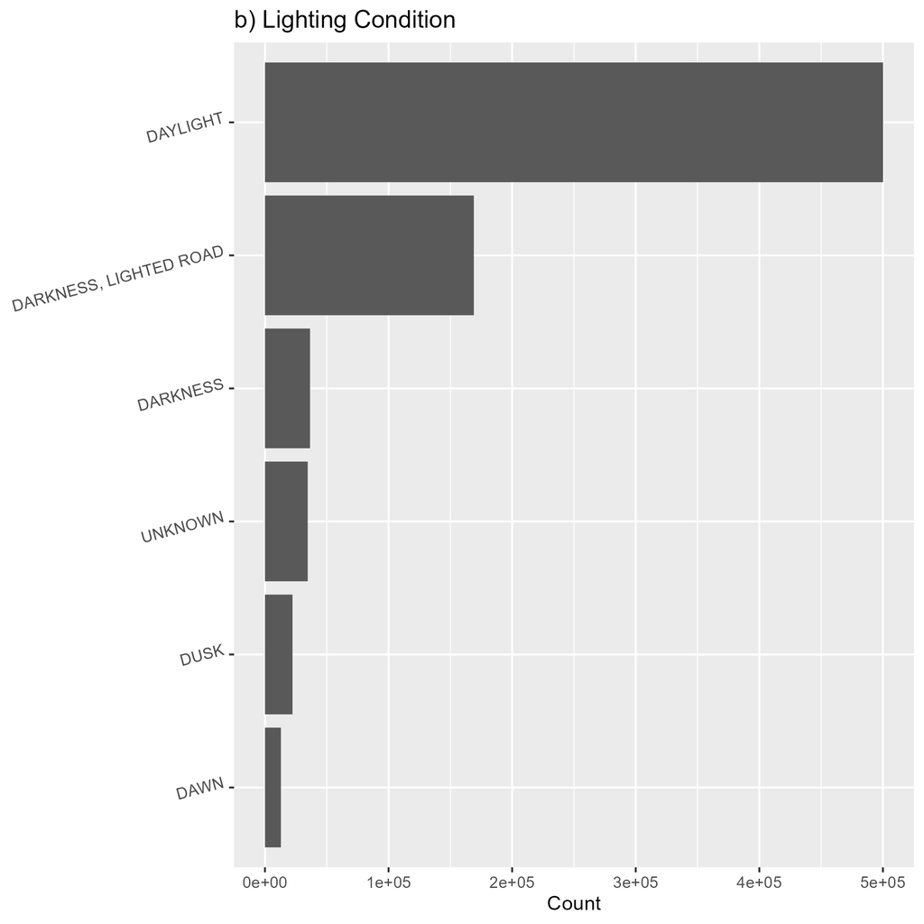

[figure not shown]

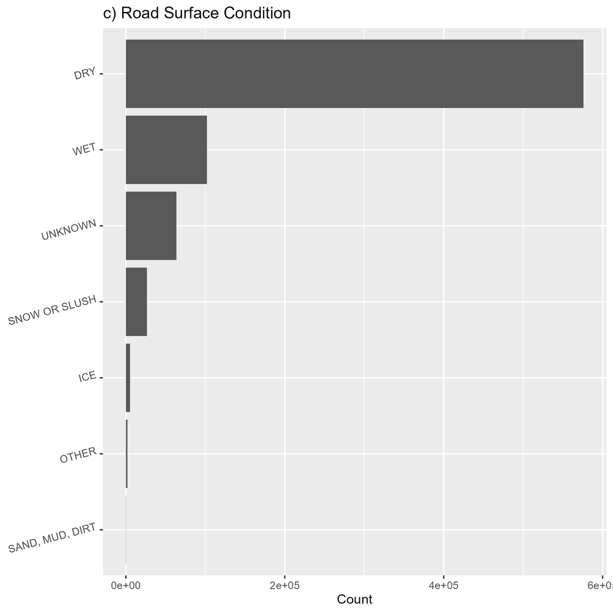

Figure 2: A series of 4 images depicting the distributions of environmental conditions of chicago crashes.

Following, I examined the recorded primary and secondary causes for crashes, presented in tables below.

Table 2: Primary and Secondary Contributory Causes in Chicago Traffic Crashes

(a) Primary

| Primary Cause | Count |
| --- | --- |
| UNABLE TO DETERMINE | 300689 |
| FAILING TO YIELD RIGHT-OF-WAY | 84893 |
| FOLLOWING TOO CLOSELY | 76060 |
| NOT APPLICABLE | 41059 |
| IMPROPER OVERTAKING/PASSING | 38102 |
| FAILING TO REDUCE SPEED TO AVOID CRASH | 32798 |
| IMPROPER BACKING | 30863 |
| IMPROPER LANE USAGE | 27981 |
| DRIVING SKILLS/KNOWLEDGE/EXPERIENCE | 25747 |
| IMPROPER TURNING/NO SIGNAL | 25735 |
| DISREGARDING TRAFFIC SIGNALS | 15060 |
| WEATHER | 11708 |
| OPERATING VEHICLE IN ERRATIC, RECKLESS, CARELESS, NEGLIGENT OR AGGRESSIVE MANNER | 9873 |
| DISREGARDING STOP SIGN | 8444 |
| DISTRACTION - FROM INSIDE VEHICLE | 5351 |
| EQUIPMENT - VEHICLE CONDITION | 4857 |
| PHYSICAL CONDITION OF DRIVER | 4656 |
| VISION OBSCURED (SIGNS, TREE LIMBS, BUILDINGS, ETC.) | 4437 |
| DRIVING ON WRONG SIDE/WRONG WAY | 4109 |
| UNDER THE INFLUENCE OF ALCOHOL/DRUGS (USE WHEN ARREST IS EFFECTED) | 3679 |
| DISTRACTION - FROM OUTSIDE VEHICLE | 3212 |
| EXCEEDING AUTHORIZED SPEED LIMIT | 1982 |
| ROAD ENGINEERING/SURFACE/MARKING DEFECTS | 1943 |
| ROAD CONSTRUCTION/MAINTENANCE | 1691 |
| EXCEEDING SAFE SPEED FOR CONDITIONS | 1684 |
| DISREGARDING OTHER TRAFFIC SIGNS | 1668 |
| EVASIVE ACTION DUE TO ANIMAL, OBJECT, NONMOTORIST | 1440 |
| CELL PHONE USE OTHER THAN TEXTING | 1045 |
| DISREGARDING ROAD MARKINGS | 953 |
| HAD BEEN DRINKING (USE WHEN ARREST IS NOT MADE) | 804 |
| ANIMAL | 650 |
| TURNING RIGHT ON RED | 575 |
| DISTRACTION - OTHER ELECTRONIC DEVICE (NAVIGATION DEVICE, DVD PLAYER, ETC.) | 365 |
| RELATED TO BUS STOP | 356 |
| TEXTING | 304 |
| DISREGARDING YIELD SIGN | 265 |
| PASSING STOPPED SCHOOL BUS | 92 |
| OBSTRUCTED CROSSWALKS | 80 |
| BICYCLE ADVANCING LEGALLY ON RED LIGHT | 79 |
| MOTORCYCLE ADVANCING LEGALLY ON RED LIGHT | 22 |

(b) Secondary

| Secondary Cause | Count |
| --- | --- |
| NOT APPLICABLE | 317513 |
| UNABLE TO DETERMINE | 280987 |
| FAILING TO REDUCE SPEED TO AVOID CRASH | 29238 |
| FAILING TO YIELD RIGHT-OF-WAY | 24065 |
| DRIVING SKILLS/KNOWLEDGE/EXPERIENCE | 23791 |
| FOLLOWING TOO CLOSELY | 20490 |
| IMPROPER OVERTAKING/PASSING | 11826 |
| IMPROPER LANE USAGE | 10915 |
| WEATHER | 8870 |
| IMPROPER TURNING/NO SIGNAL | 7882 |
| IMPROPER BACKING | 6252 |
| OPERATING VEHICLE IN ERRATIC, RECKLESS, CARELESS, NEGLIGENT OR AGGRESSIVE MANNER | 4928 |
| DISREGARDING TRAFFIC SIGNALS | 3133 |
| VISION OBSCURED (SIGNS, TREE LIMBS, BUILDINGS, ETC.) | 2460 |
| PHYSICAL CONDITION OF DRIVER | 2408 |
| DISTRACTION - FROM INSIDE VEHICLE | 2342 |
| DISREGARDING STOP SIGN | 2276 |
| DRIVING ON WRONG SIDE/WRONG WAY | 1594 |
| EQUIPMENT - VEHICLE CONDITION | 1571 |
| EXCEEDING AUTHORIZED SPEED LIMIT | 1473 |
| EXCEEDING SAFE SPEED FOR CONDITIONS | 1438 |
| DISTRACTION - FROM OUTSIDE VEHICLE | 1301 |
| UNDER THE INFLUENCE OF ALCOHOL/DRUGS (USE WHEN ARREST IS EFFECTED) | 1273 |
| HAD BEEN DRINKING (USE WHEN ARREST IS NOT MADE) | 966 |
| ROAD CONSTRUCTION/MAINTENANCE | 923 |
| DISREGARDING OTHER TRAFFIC SIGNS | 794 |
| DISREGARDING ROAD MARKINGS | 789 |
| ROAD ENGINEERING/SURFACE/MARKING DEFECTS | 770 |
| CELL PHONE USE OTHER THAN TEXTING | 586 |
| EVASIVE ACTION DUE TO ANIMAL, OBJECT, NONMOTORIST | 421 |
| ANIMAL | 367 |
| RELATED TO BUS STOP | 351 |
| TURNING RIGHT ON RED | 298 |
| DISTRACTION - OTHER ELECTRONIC DEVICE (NAVIGATION DEVICE, DVD PLAYER, ETC.) | 231 |
| BICYCLE ADVANCING LEGALLY ON RED LIGHT | 227 |
| DISREGARDING YIELD SIGN | 198 |
| TEXTING | 140 |
| PASSING STOPPED SCHOOL BUS | 89 |
| OBSTRUCTED CROSSWALKS | 80 |
| MOTORCYCLE ADVANCING LEGALLY ON RED LIGHT | 55 |

Failing to yield right-of-way, following-too closely, improper overtaking/passing, failing to reduce speed to avoid crash, and improper backing make up the five largest non-unknown primary reasons behind a traffic crash, and make up four out of five largest non-unknown secondary reasons for a traffic crash. It is important at this point to acknowledge that “Unable to determine” and “Not applicable” are listed as either the primary and secondary cause amongst the vast majority of crashes that the data is unable to fully capture the often-complex events leading up to a crash.

It is encouraging to note that crashes caused by technology-related distractions do not make up a large proportion of the crashes in this dataset. Out of the 40 different types of contributory causes, cell phone use other than texting ranks 28th as a primary cause, and texting ranks 35th.

Figure 3a-c depict the distribution of crashes at different times in the day, hours in a week, and months of the year, which reveals that crashes peak in the mid-afternoon at 3pm, on Fridays, and during the month of October.

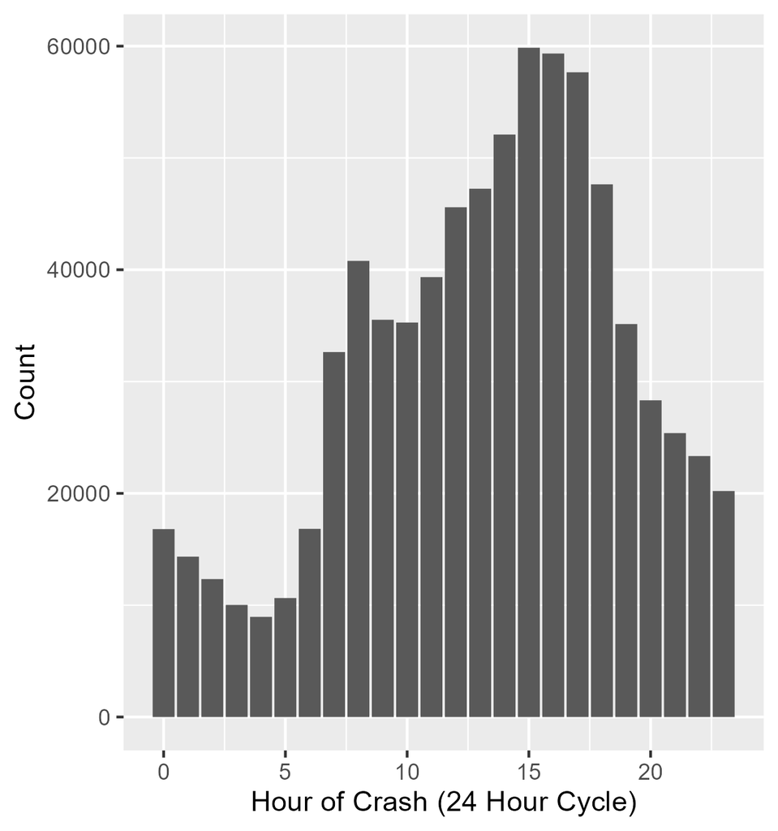

(a) Hourly Distribution

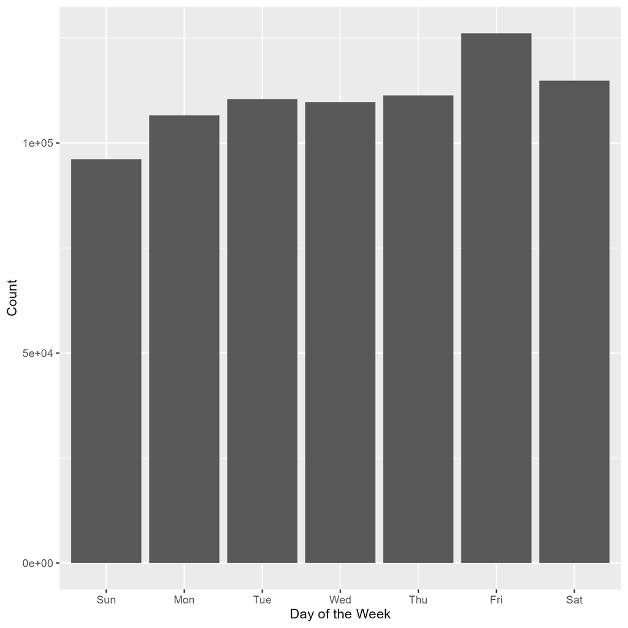

(b) Weekly Distribution

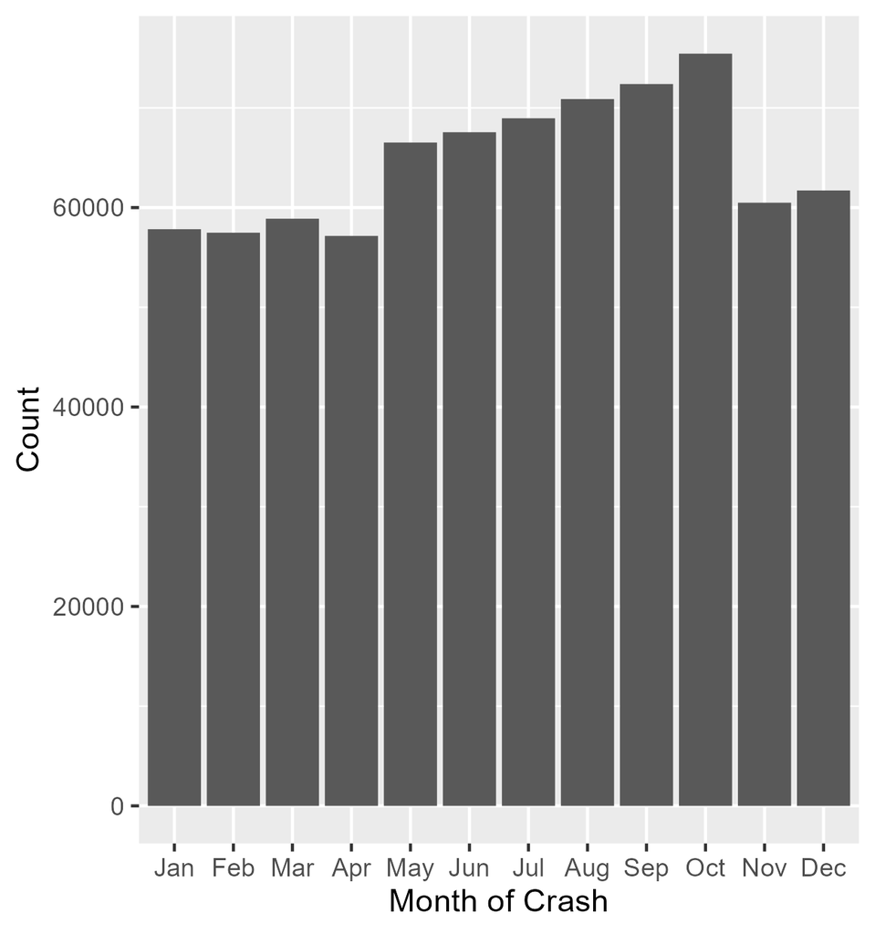

(c) Monthly Distribution

Figure 3: Crash distributions at hour, week, and month levels.

These plots echo an important distinction that must be made when proceeding with analysis, which is the question of whether crashes occur more frequently at a certain time or under a certain condition because of that particular time/condition or because there are simply more cars around at that time. For example, the fact that crashes occur most frequently between 3-5pm is likely because there are more cars on roads during the afternoon rush hour, not that there is something inherently dangerous about this time.

Unfortunately for the data analyst, the tameness of these results are somewhat dissatisfying, Thus, the remainder of the report will explore deeper connections between the various causes of crashes, environmental conditions, and injury severity found within the dataset.

## 4 Looking Deeper

### 4.1 How do crash severity and type correlate?

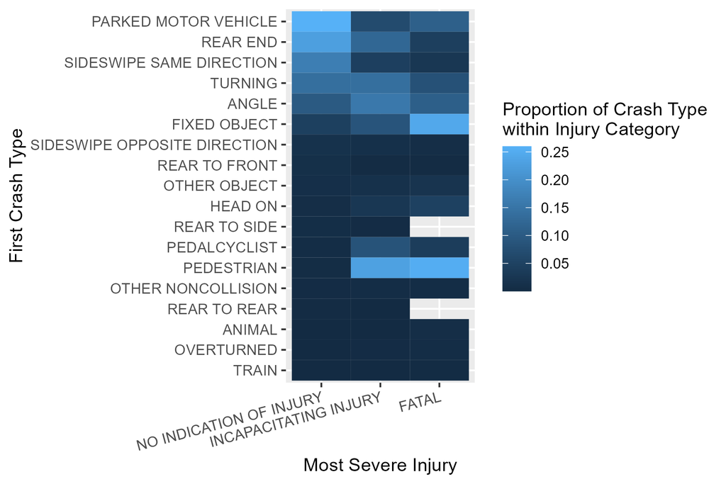

Figure 4: Type vs. Most Severe Injury Frequency

### 4.2 What causes of crashes produce the greatest number of injuries?

Injury severity can also be categorized by how many injuries are caused in the accident, which I examine in Figure 5 against their primary contributing causes. Due to the number of levels in the primary contributory cause variable, I have grouped similar causes together for improved readability in visualization. The complete groupings can be found in the `5_final_figures_tables.R` script in the Github repository. Here, it is evident that driver-dependent causes such as improper driving, disregarding signs, and driver condition (including physical condition and aggressive behavioral) are the primary drivers of the number of injuries in a car crash. Environmental conditions such as weather, external vision obstructions, and other presences outside of the care account for relatively fewer injury-causing crashes.

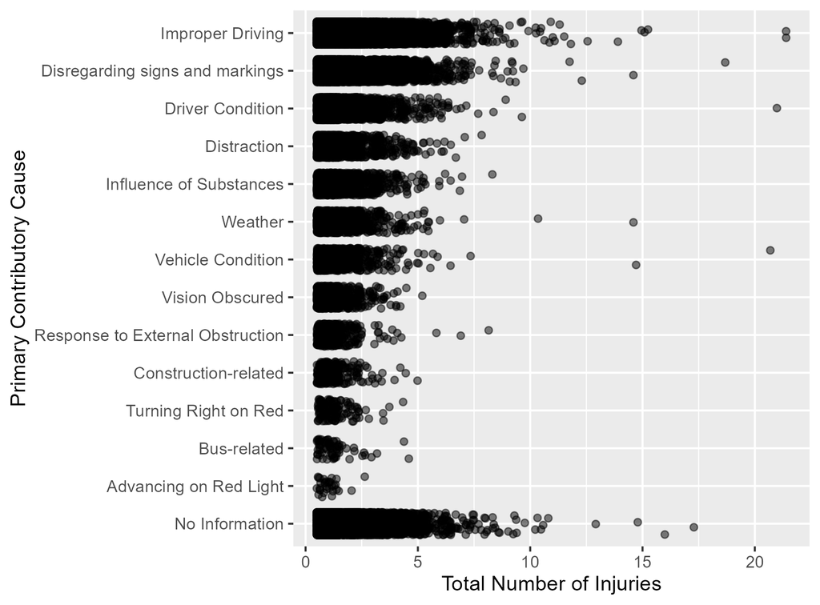

Figure 5: Cause vs. Injury Frequency

### 4.3 Does the occurrence of weather as a contributory cause fluctuate by season?

I was initially surprised in Figure 3 (c) that there were fewer crashes during the winter months, where ice and inclement weather would make proper driving difficult. However this may be due to a reduced number of cars on roads during the winter month, which would obscure changes in the rate of occurrence for each cause listed in the dataset. Figure 6 resolves these with a stacked bar chart. I have isolated weather-related contributory causes from the list of primary contributory causes, and indeed there is an increase in the number of weather-related crashes during November, December, January, and February despite the fewer number of incidents overall.

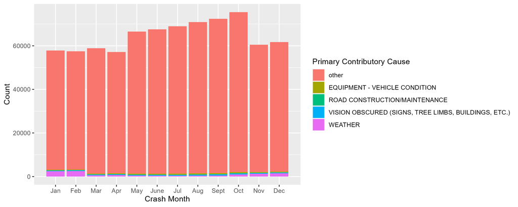

Figure 6: Bar chart revealing more weather-related crashes during winter months

### 4.4 Do certain weather conditions result in more severe injuries than others?

Relatedly, it may be worthwhile to examine this kind of trend in all weather conditions. Figure 7 depicts a tile plot of the number of crashes occurring under different combinations of weather and injury severity. If a particular type of weather frequently led to more severe injuries, one would expect the tile at the intersection of the two variables to consistently be brighter. In the leftmost tile plot, all weather conditions represented in the dataset are kept on the plot, which shows that the brightest row, attributed to the weather condition recorded most often, remains consistently bright across all injury types for the most commonly reported injury conditions, leading to the conclusion that weather does not cause significant differences in injury severity. This unfortunately obscures subtle differences in the remaining weather condition rows, and is likely due to the disproportionate number of crashes recorded on days with these weather patterns. But, when the five most common weather conditions (clear, rain, overcast, snow, and unknown) are removed on can see subtle differences in fatality based upon weather. From the figure below, it appears that blowing snow, fog/smoke/haze, and severe wind disproportionately produce fatal crashes.

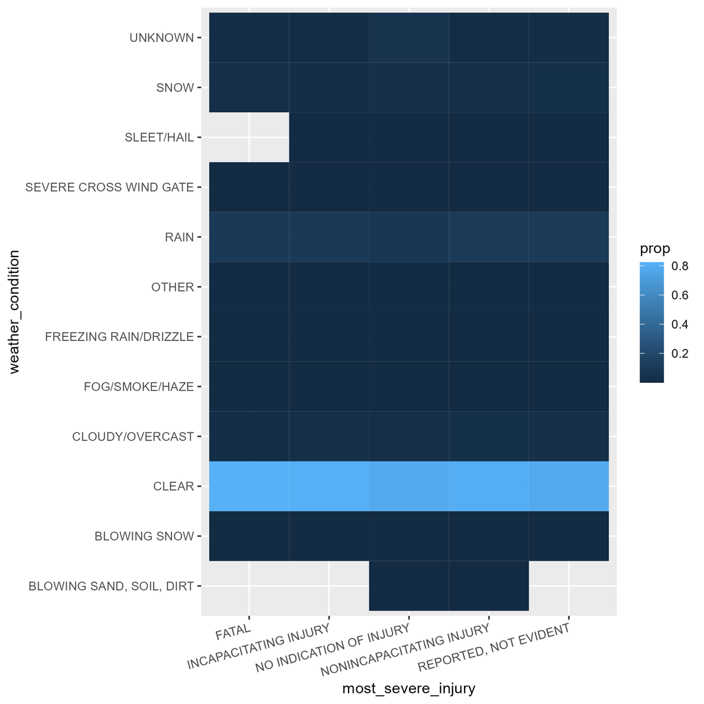

All weather conditions

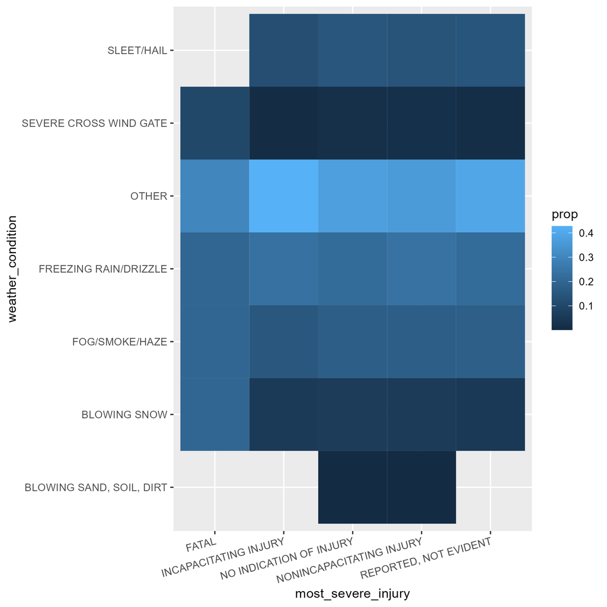

Without top 5 weather conditions

Figure 7: Tile plots depicting crashes of different severity under different weather conditions.

### 4.5 Are there differences between daytime and nighttime crashes?

I initially anticipated more crashes at night due to lower visibility, and the potential of bright lights making driving more difficult. Therefore I repeated the analysis conducted in Figure 6 to investigate primary contributory causes which occur more often at night. This figure uses a proportionally filled bar chart to visualize changes in the rate of occurrence for nighttime-relevant primary contributory causes for crashes recorded at each hour of the day. The primary causes are grouped again using the groupings seen in Figure 5 for improved readability, and illustrates that substance abuse-related crashes, rather than impaired visibility, occur disproportionately at night. Curiously enough, obscured vision crashes actually increase between 6-10am each day.

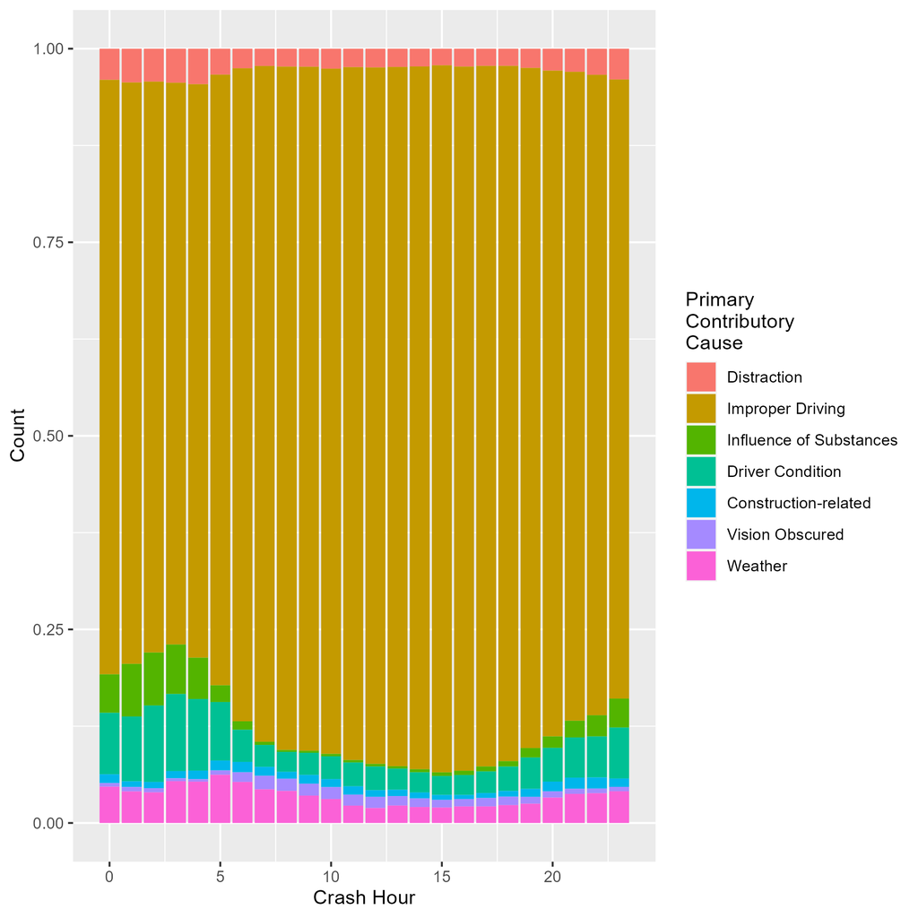

Figure 8: Proportional bar chart of nighttime-relevant crash cause fluctuations throughout the day.

### 4.6 How do crashes at different speeds involving different numbers of units differ in injury severity?

Figure 9 depicts a relationship between two of the few numeric variables in this dataset, plotting the number of units involved in the crash on the y-axis and posted speed limit at the site of the crash on the x. While it may have been more informative to visualize the speed of the crash to better understand fatality, the information presented here show that most crashes occur in regions where the speed limit is around 30mph. This I believe concurs with the findings found in Section 3.1, in that the majority of under very “typical” road conditions; in this case it indicates that crashes of all fatalities occur on local roads, which make up a larger proportion of the infrastructure found in Chicago. I am uncertain where the outlier values plotted at posted speed limits of ~100mph may have come from, as I have never seen a road with a posted speed limit that high. I would like to attribute these to a data collection error, although further investigation might be warranted.

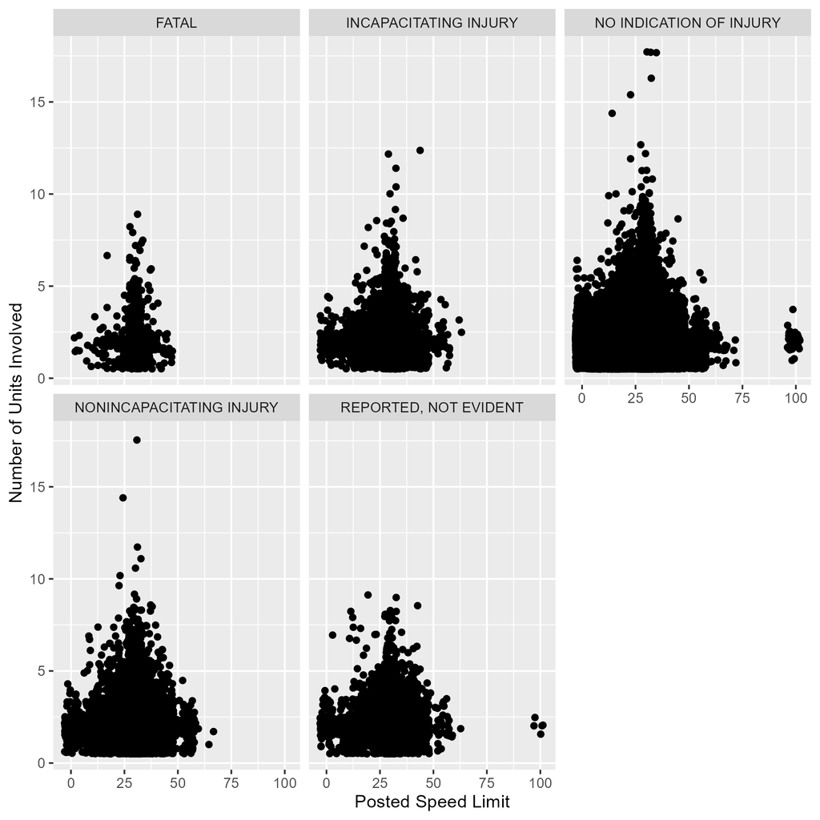

Figure 9: Scatterplot of units in crash versus posted speed limit, faceted by most severe injury

### 4.7 Aside: When are Crashes Being Reported?

Although not terribly relevant to understanding the main predictors of crashes in Chicago, this dataset contained information on when crashes occurred and when crashes were reported to the police, which allows for investigating any trends in the delay between these two events. Below are histograms depicting the distribution of delay for crashes reported within the day and within the week, as well as the distribution of all recorded delays, where readers can see a curious pattern emerge.

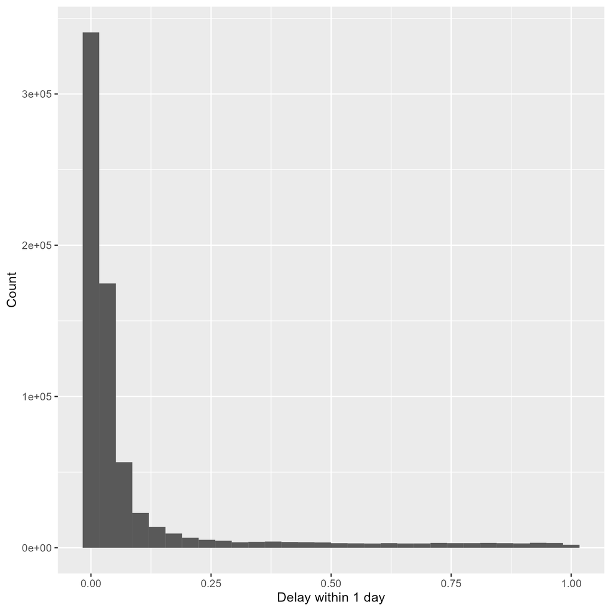

(a) Within a Day

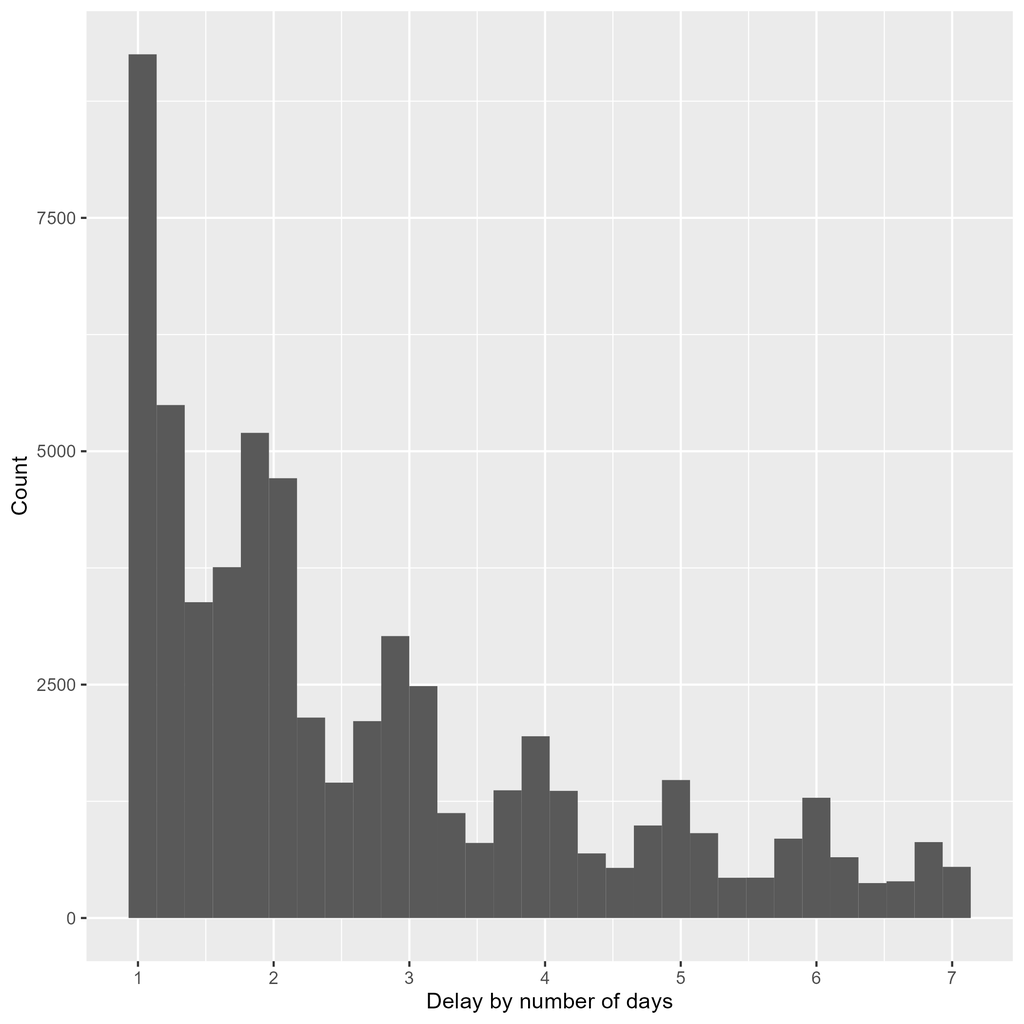

(b) Within a Week

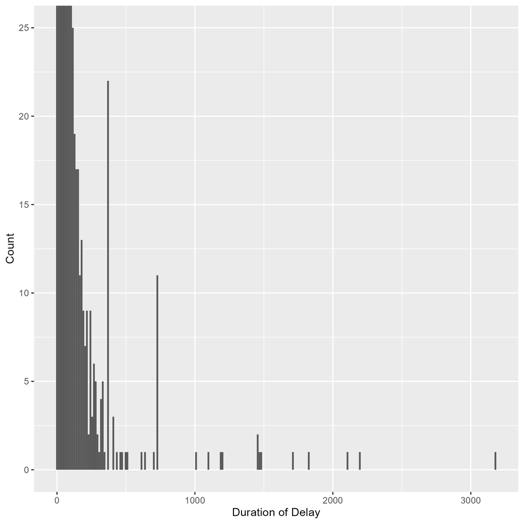

(c) All delay

Figure 10: Distributions of reporting delay within the day, week, and all delays.

All histograms are skewed right, understandably because those involved in the crashes would likely want to report and document their crash as soon as possible, but especially in the delay reported within the week we observe curious peaks in delay at “whole number” units of delay. A similar pattern can be found in Figure 10 (c), which contains peaks at delays reported at 1, 2, and 4 years post-crash (365, 730, and 1460 days, respectively) before the number of crashes reported becomes too small to notice a difference in cases of longer report delays.

### 4.8 Where are crashes occurring?

The final component of this EDA report is an interactive map of crashes from 2023, created with the help of the `mapview` library and with instructions from the Duke University Center for Data & Visualization.<sup>2</sup>

For ease of discussion, all traffic crashes have first been plotted on a static map of Chicago. The map shows an unusual cluster of crashes within the Oak Park and West Garfield Park regions of the city (to the west just under 41.9 degrees N), as well as the Chatham region (to the south in the middle between 41.7 and 41.8 degrees N) and a smaller cluster around downtown Chicago.

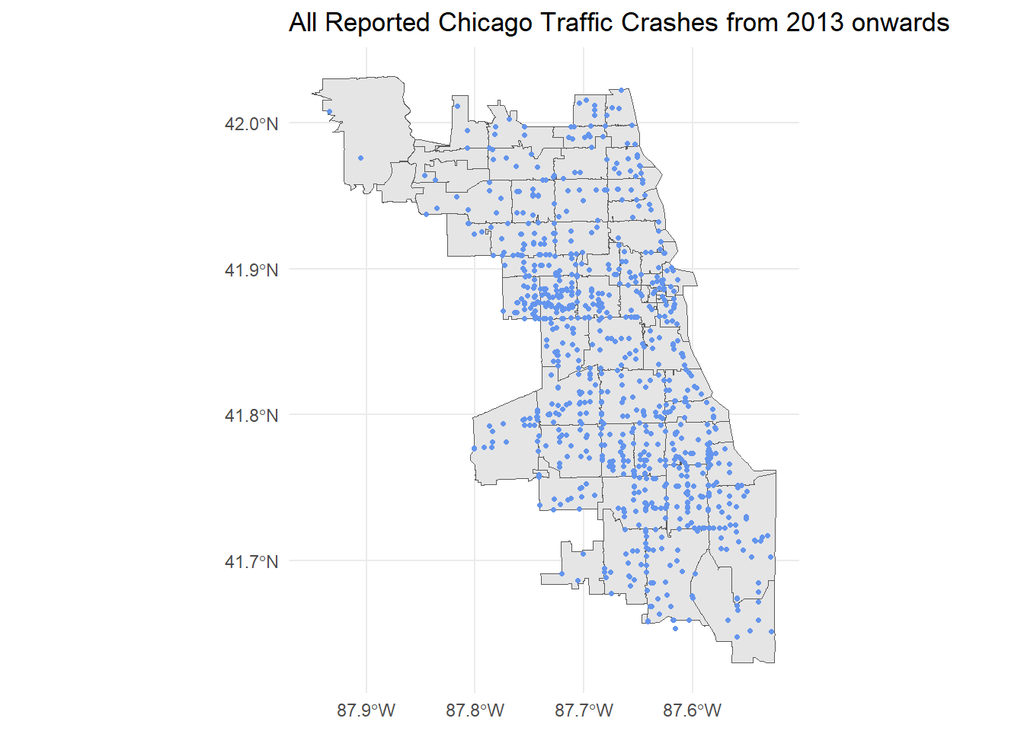

For greater resolution, the table below contains the top 10 most-recorded street addresses, and the number of crashes recorded at each location. Curiously, these top street addresses do not concur with the clusters represented by the map above, which may be due to an issue of not all the recorded crashes containing longitude and latitude data.

Table 3: Addresses of Top 10 Crash Locations

| Address | Number of Crashes |
| --- | --- |
| 10000 W OHARE ST | 1232 |
| 5700 S LAKE SHORE DR | 551 |
| 7900 S STONY ISLAND AVE | 539 |
| 9500 S STONY ISLAND AVE | 422 |
| 1000 N LAKE SHORE DR SB | 401 |
| 3 W TERMINAL ST | 381 |
| 7601 S CICERO AVE | 365 |
| 1 W TERMINAL ST | 345 |
| 1000 N LAKE SHORE DR NB | 307 |
| 5700 S CICERO AVE | 298 |

An interactive map is also included below for the reader to explore at will.

[interactive chart not shown]

## 5 Conclusion

To conclude, this data exploration shows that the vast majority of traffic incidents reported to the City of Chicago occur in very normal weather conditions and do not result insignificant injury. However, for those that do result in injury, most are due to the behavior of the driver rather than an external threat. The most fatal type of of crash are those which involve pedestrians. Weather becomes a more pressing issue during the winter, and there is a curious trend of people reporting crashes on whole-number units after the crash. There exist some regional areas with a high frequency of crashes, namely to the West, downtown, and South of Chicago. If given more time, I would have liked to investigate further on the reasons for these regional clusters of crashes as I outlined in my second progress memo. These findings could potentially uncover road design flaws which may contribute to the frequency of crashes at these locations. Furthermore, it would have been more satisfying to look into why the mapped crashes in Figure 11 did not concur with the street addresses listed in Table 3, which may have required further data collection efforts.

The only finding I am particularly concerned about is the discovery that substance-related crashes occur more frequently at night. This could point to a need for potential policy improvements to reduce dangerous driving due to substance abuse in Chicago.

All in all, these findings do not suggest anything particularly out of the ordinary with the behavior of Chicago drivers. Even if some findings are somewhat unusual at first, they can each be explained reasonably. Perhaps the culture shock I experienced when I came to college was just part of moving to a larger city.

## 6 References

1. City of Chicago (2023, November 29). Traffic Crashes - Crashes. Chicago data Portal. https://data.cityofchicago.org/Transportation/Traffic-Crashes-Crashes/85ca-t3if.
2. Duke University Center for Data & Visualization. Latitude and Longitude Coordinates. Mapping in R. https://map-rfun.library.duke.edu/01_georeference.